# Medidas de tendencia central

[Jessica Julieta Martínez Guadarrama](https://jessimart.github.io)

Estadística 2022-2, [Facultad de economía](http://www.economia.unam.mx/)

2/3/2022

### 1. ¿Qué son las medidas de tendencia central? 🤔

> Definición: “Las medidas de tendencia central son valores numéricos que tienden a localizar la parte central de un conjunto de datos. Cada una de ellas ofrece un *centro* de la distribución de frecuencias, lo que implica que representa un valor que se puede tomar como representativo de todos los datos.”

[UNAM (2022)](http://prepa8.unam.mx/academia/colegios/matematicas/paginacolmate/applets/matematicas_IV/Applets_Geogebra/medtencen.html)

Para este ejemplo, primero generaremos una serie de **100** números aleatorios entre **1** y **20** mediante la función `sample`. El argumento `TRUE` nos permitirá generar una muestra con remplazo:

```r
numeros <- sample(1:20, 100, TRUE)
numeros
```

```
##   [1]  4  2 17 20 18  4  1 12 13  4 16  2 16  6 12 15  8 17  9 20  9 16  3  9  7
##  [26]  1 11 11 20  9 14  5  3  2  4 11 11 20  3 19  7 17  1  5 18  9 18 11  8 11
##  [51]  7  4  7  9  7  3  5  9  8 10 17 10  5 11  2 14  2  9  8  4  6 13 16  8 19
##  [76] 18  3  8  6  2  8  4 19  8  2 15  4 11 14 19 19  9  3  3  6 17  5 18  5  7
```

### 2. Mediana 📍

> Definición: “Se denomina mediana en estadística al valor que se encuentra en el lugar central de todos los datos de un estudio cuando éstos están ordenados de menor a mayor. La mediana es por tanto el número central de un grupo de números ordenados por su tamaño.”

[UNAM (2022)](http://prepa8.unam.mx/academia/colegios/matematicas/paginacolmate/applets/matematicas_IV/Applets_Geogebra/medtencen.html)

Para obtener la **mediana**, podemos ordenar los `numeros` de menor a mayor, **el número que esté en medio de la muestra será la mediana**. Si utilizamos R, se puede hacer el cálculo de la **mediana** con la función `median`:

```r
mediana <- median(numeros)
mediana
```

```
## [1] 9
```

### 3. Media 🧮

> Definición: “También denominada *promedio*, es la que se utiliza principalmente y se define como la suma de los valores de todas las observaciones divididas por el número total de datos.”

[UNAM (2022)](http://prepa8.unam.mx/academia/colegios/matematicas/paginacolmate/applets/matematicas_IV/Applets_Geogebra/medtencen.html)

$$Media ={\frac {1}{n}}\sum _{i=1}^{n}a_{i}={\frac {a_{1}+a_{2}+\cdots +a_{n}}{n}}$$

Si usamos R, podemos obtener la media de una muestra si utlilizamos la función **mean**:

```r
media <- mean(numeros)
media
```

```
## [1] 9.55
```

### 4. Moda 📊

> Definición: “  
> La *moda* se define como aquel valor o valores que más se repiten entre los datos que se han obtenido en una muestra.”

[UNAM (2022)](http://prepa8.unam.mx/academia/colegios/matematicas/paginacolmate/applets/matematicas_IV/Applets_Geogebra/medtencen.html)

Podemos saber cuál es la **frecuencia** (número de veces que aparece un elemento en una muestra) de cada número si dibujamos un **histograma** con la función `hist`, **aquel elemento con mayor frecuencia será la moda**:

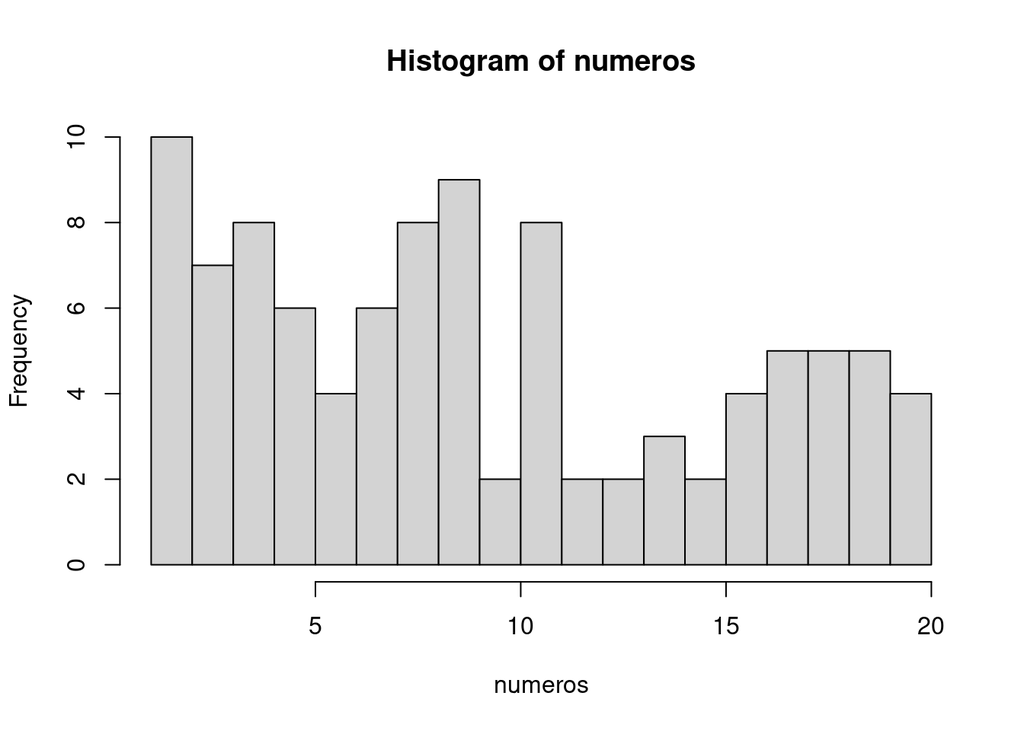

```r
# El argumento breaks nos permite dividir en histograma en las partes que queramos
hist(numeros, breaks = 20)
```

Para obtener un resultado con más precisión, podemos obtener la **moda** si generamos una **tabla de frecuencias** con la función `table` y la función `data.frame`, **aquel elemento con mayor frecuencia será la moda**:

```r
tabla.frecuencias <- data.frame(table(numeros))
tabla.frecuencias
```

```
##    numeros Freq
## 1        1    3
## 2        2    7
## 3        3    7
## 4        4    8
## 5        5    6
## 6        6    4
## 7        7    6
## 8        8    8
## 9        9    9
## 10      10    2
## 11      11    8
## 12      12    2
## 13      13    2
## 14      14    3
## 15      15    2
## 16      16    4
## 17      17    5
## 18      18    5
## 19      19    5
## 20      20    4
```

### 5. Ejercicio 👩‍💻👨‍💻✍

Aplica lo que aprendiste, obten la **mediana**, **media** y **moda** de la siguiente muestra de números:

```r
# Con la función seq, creamos una secuencia de 1 a 10 en intervalos de 0.1 en 0.1
secuencia <- seq(1, 10, 0.1)
muestra <- sample(secuencia, 100, TRUE)
muestra
```

```
##   [1]  4.3  3.2  4.7  6.8  4.7  3.7  2.3  5.4  8.3  1.8  6.8  6.0  7.0  9.7  2.4
##  [16]  2.8  5.1  1.6  4.4  7.1  3.3  2.1 10.0  3.1  6.3  5.3  6.8  5.7  4.2  6.2
##  [31]  9.9  6.0  8.6  7.2  6.5  5.3  3.4  5.3  9.2  8.8  9.9  2.4  3.9  8.6  5.0
##  [46]  6.9  7.1  9.8  8.0  4.0  1.5  2.7  7.0  6.8  2.8  7.1  1.1  2.0  4.5  8.4
##  [61]  1.7  2.6  2.0  6.4  9.2  7.6  6.1  1.7  5.7  4.5  2.6  7.0  4.7  7.7  8.2
##  [76]  6.7  1.0  4.0  1.9  6.8  9.8  8.2  7.3  1.2  2.8  3.6  5.5  9.9  9.4  3.7
##  [91]  2.8  9.5  1.3  7.8  8.1  2.5  5.9  2.9  8.8  3.3
```

##### Mediana

```r
# Aquí el cálculo de la mediana
mediana.muestra<- median(muestra)
mediana.muestra
```

```
## [1] 5.45
```

##### Media

```r
# Aquí el cálculo de la media
media.muestra <- mean(muestra)
media.muestra
```

```
## [1] 5.432
```

##### Moda

```r
# Aquí el cálculo de la moda
tabla.muestra <- data.frame(table(muestra))
tabla.muestra
```

```
##    muestra Freq
## 1        1    1
## 2      1.1    1
## 3      1.2    1
## 4      1.3    1
## 5      1.5    1
## 6      1.6    1
## 7      1.7    2
## 8      1.8    1
## 9      1.9    1
## 10       2    2
## 11     2.1    1
## 12     2.3    1
## 13     2.4    2
## 14     2.5    1
```

[output cut: 54 more lines]

```r
moda.muestra <- 6.8
moda.muestra
```

```
## [1] 6.8
```

💻[Código disponible en RStudio Cloud](https://rstudio.cloud/project/3671022)💻